# Excitation and Ionization

Author

Daniel Fischer

# Introduction

Up to this point, we have mainly discussed the **static structure of atoms** — their energy levels, term symbols, and how these arise from electron–electron and spin–orbit interactions. However, the **dynamics** of how atoms respond to external perturbations is just as fundamental:  
How do atoms become **excited** or **ionized**?  
What are the **probabilities** and **timescales** of such processes?  
How do atomic configurations **rearrange** once an electron is promoted or removed?

Atoms can be excited or ionized through two main mechanisms:

- **Absorption of photons** (radiative excitation or photoionization)
- **Collisions** with electrons, ions, or neutral particles (impact excitation or collisional ionization)

Understanding these processes is a central theme in **atomic, molecular, and optical (AMO) physics**. They play a key role in a wide range of applications — from **astrophysical plasma diagnostics**, **laser spectroscopy**, and **radiation damage in biological systems**, to **quantum information processing** and **precision metrology**.

In this chapter, we will not attempt to cover the full complexity of atomic excitation and scattering. Instead, we will focus on a few **simple but representative scenarios** that illustrate the underlying physics and connect to real-world experiments.

# 1. Single-Electron Excitation

In many atoms, low-lying excited configurations can be described as **single-electron excitations**: one electron is promoted to a higher orbital while the rest of the atom remains in its ground-state configuration. This picture relies on the **independent-electron approximation**, where each electron moves in an effective potential generated by the nucleus and the average field of the other electrons.

> **Note:**  
> The term *“singly excited configuration”* typically refers to states where **exactly one electron** occupies a higher orbital than in the ground state. In contrast, *excited terms* within the same configuration (arising from different couplings of $L$ and $S$) are not considered “singly excited configurations,” even though their energies differ.

However, because the electrons interact via the Coulomb force, changing the state of one electron **modifies the entire potential**, so the single-electron model is only an approximation.

## 1.1 Example: Beryllium

Beryllium provides a simple example. Its **ground-state configuration** is:

$$1s^2 2s^2 \quad ({}^1S_0)$$

The lowest **singly excited configurations** involve promoting one of the $2s$ electrons to a $2p$ or higher orbital:

[output not shown]

## 1.2 Typical Lifetimes of Excited States

The **lifetime** of an excited state is inversely proportional to its **radiative decay rate** $A_{21}$:

$$A_{21} \propto \omega^3 |\langle 1 | \hat{r} | 2 \rangle|^2,$$

which means that higher transition frequencies $\omega$ and stronger dipole matrix elements lead to faster decays.

| Atom / Transition | Lifetime ($\tau$) | Energy ($\hbar\omega$) |
| --- | --- | --- |
| H ($2^2P_{3/2} \to 1^2S_{1/2}$) | 1.5 ns | 10.2 eV |
| He ($2^1P_1 \to 1^1S_0$) | 0.5 ns | 21.2 eV |
| Na ($3^2P_{1/2} \to 3^2S_{1/2}$) | 16 ns | 2.1 eV |

In atomic units, the binding energy of a Rydberg state scales approximately as $E_n \propto 1/n^2$, so the **energy spacing** between adjacent levels decreases rapidly with increasing $n$. This implies that radiative transitions between *nearby* Rydberg levels involve smaller photon energies and generally weaker dipole coupling. A detailed analysis—taking into account both the scaling of dipole matrix elements and the density of accessible final states—shows that the corresponding **lifetimes increase roughly as $n^3$**. This often-cited scaling, however, is **not obvious** from simple arguments and depends on assumptions about which decay channels dominate and how many are available.

Importantly, this $n^3$ scaling applies primarily to transitions between neighboring states of similar orbital angular momentum $\ell$. Low-$\ell$ Rydberg states (such as $s$ or $p$ states) can also decay directly to the ground state via **high-frequency dipole transitions** with large $\omega$, which shortens their lifetimes dramatically. In contrast, **high-$\ell$ states**—which have poor radial overlap with the ground state and are often **dipole-forbidden** for large $\Delta \ell$—are **metastable**, exhibiting lifetimes that can reach **microseconds to milliseconds**, even in light atoms.

Thus, the long lifetimes of Rydberg states arise not simply from the $1/n^2$ energy scaling, but from a combination of **small level spacings** and **restricted dipole coupling** due to angular momentum and selection-rule effects.

## 1.3 Metastable States

Some excited states have **very long lifetimes** because the lowest-order (electric-dipole) transitions to lower levels are **forbidden** by the selection rules. As a result, decay must proceed via **higher-order** processes (magnetic dipole, electric quadrupole, or even two-photon transitions), or via weak mixing with allowed states — all of which lead to much smaller transition rates and therefore long lifetimes.

| Atom / State | Lifetime ($\tau$) | Decay Type |
| --- | --- | --- |
| H ($2^2S_{1/2}$) | 8 s | Two-photon decay |
| He ($2^1S_0$) | 19.6 ms | Two-photon decay |
| He ($2^3S_1$) | 7870 s | Magnetic dipole (M1) |

Such **metastable levels** play a crucial role in many areas of atomic physics. Because their radiative decay is strongly suppressed, they can **store population** for long times — a prerequisite for **population inversion** and thus for **lasing**. In some special cases, such as metastable helium, these long-lived states can also serve as effectively stable starting points for **laser cooling** and **precision spectroscopy**, since they can be selectively excited and manipulated without rapid decay.

# 2. Doubly Excited States

An atom is said to be **doubly excited** when *two* of its electrons are promoted from their ground-state configuration. Such configurations reveal strong **electron–electron correlations**, since both excited electrons interact not only with the ionic core but also strongly with each other. They represent an important step beyond the **independent-electron model** introduced for singly excited states.

## 2.1 Example: Doubly Excited States in Beryllium

We have already encountered **beryllium (Be)** in the previous section, where single-electron excitations could be described fairly well within the **independent-electron approximation**. However, this picture begins to fail when *two* electrons are excited simultaneously. In that case, the interaction between the two excited electrons becomes crucial, and their motion can no longer be treated independently — leading to strongly **correlated, doubly excited states**.

### Ground-State Configuration

The ground state of beryllium is:

$$1s^2 2s^2 \; ({}^1S_0)$$

Here both $1s$ and $2s$ subshells are completely filled, resulting in a closed-shell singlet ($S=0$, $L=0$).

### Doubly Excited Configurations

If we excite **both 2s electrons**, several configurations become possible, such as:

$$1s^2 2p^2$$

These states have two electrons in the $2p$ subshell and therefore allow multiple possible term symbols depending on how the angular momenta couple:

$$1s^2 2p^2 \rightarrow {}^1S_0, \; {}^1D_2, \; {}^3P_{0,1,2}.$$

Each term represents a different total spin $S$ and orbital angular momentum $L$ combination that can arise from coupling two $p$ electrons. For example:  
- The **${}^1D_2$** and **${}^1S_0$** are **singlet** states ($S=0$),  
- while the **${}^3P_J$** terms ($S=1$) form a **triplet**.

Because all these states share the same electronic configuration, their **energy differences** arise solely from **electron–electron interactions** (Coulomb and exchange effects), with smaller contributions from spin–orbit coupling. Hence, they serve as an excellent example to illustrate **correlation effects** in multi-electron atoms.

### Energetics

Approximate energy ordering (in eV, relative to the ground state):

| Configuration | Term | Energy (eV) | Comment |
| --- | --- | --- | --- |
| $1s^2 2p^2$ | ${}^1S_0$ | 9.45 | Doubly excited |
| $1s^2 2p^2$ | ${}^3P_{0,1,2}$ | 7.40 | Doubly excited |
| $1s^2 2p^2$ | ${}^1D_2$ | 7.05 | Doubly excited |
| $1s^2 2s2p$ | ${}^1P_1$ | 5.28 | Singly excited |
| $1s^2 2s2p$ | ${}^3P_{0,1,2}$ | 2.73 | Singly excited |
| $1s^2 2s^2$ | ${}^1S_0$ | 0.00 | Ground state |
| — | — | 9.32 | Ionization threshold |

> *Note: Despite Hund’s rule predicting the triplet state (${}^{3}P$) to be lower in energy, the observed $1s^{2}2p^{2}$ excited state of beryllium shows a reversed ordering where the singlet state (${}^{1}D$) is lower. This can occasionally happen for excited states in light atoms, where strong quantum mechanical mixing between electron configurations, known as configuration interaction, can significantly alter the expected energy levels.

## 2.2 Radiative Decay Channels

**Doubly excited states** lying *below* the first ionization threshold decay **radiatively** back to the ground state.

For the $1s^2 2p^2$ configuration in beryllium, a direct one-photon decay from ${}^1D_2 \rightarrow {}^1S_0$ is electric-dipole forbidden because it violates the dipole selection rule $\Delta L = \pm 1$. However, these doubly excited states can decay efficiently via a two-step cascade through singly excited intermediate states, such as:

$$1s^2 2p^2 \; ({}^1D_2) \;\longrightarrow\; 1s^2 2s2p \; ({}^1P_1) + h\nu_1 \;\longrightarrow\; 1s^2 2s^2 \; ({}^1S_0) + h\nu_2.$$

Both transitions in this cascade are electric-dipole allowed, making the overall decay rate relatively fast (lifetimes typically on the order of nanoseconds). While direct two-photon emission—where the atom simultaneously emits two photons whose combined energy matches the energy difference between initial and final states—remains possible in principle, the cascade pathway dominates due to its much higher transition rate.

In contrast, the **triplet states** such as $1s^2 2p^2 \; ({}^3P_{0,1,2})$ cannot easily decay to the singlet ground state $1s^2 2s^2 \; ({}^1S_0)$ because electric-dipole transitions require $\Delta S = 0$. Their decay therefore proceeds only via **spin-forbidden intercombination transitions** or weak **magnetic-dipole (M1)** or **electric-quadrupole (E2)** processes, resulting in **much longer lifetimes** than for the corresponding singlet states.

## 2.3 Autoionization

When a **doubly excited state** lies *above* the first ionization threshold, it becomes energetically unstable with respect to electron emission. In such cases, the atom can decay by transferring energy from one excited electron to the other—causing one electron to relax while the other escapes to the continuum. This **radiationless decay** process is known as **autoionization**.

In the independent electron picture (left), each electron occupies an orbital with a specific energy. A doubly excited state such as $2s^22p^2\,{}^1S$ has both electrons in excited orbitals. The total electronic energy of the atom is shown in the two diagrams on the right. Doubly excited states lying above the first ionization threshold (hatched continuum region) can autoionize by ejecting one electron, transitioning from Be$^{**}$ to Be$^+$.

[figure not shown]

### Example: Autoionization of the ${}^1S_0$ Doubly Excited State in Be

In beryllium, the **${}^1S_0$** state of the $1s^2 2p^2$ configuration lies around **9.45 eV**, slightly *above* the ionization threshold at **9.32 eV**. Because it lies above this limit, the state is **embedded in the continuum** of singly ionized configurations such as $1s^2 2s \, \varepsilon p$.

The dominant decay channel is therefore **autoionization**:

$$1s^2 2p^2 \; ({}^1S_0)
\;\longrightarrow\;
1s^2 2s \; ({}^2S_{1/2}) + e^-,$$

or, in shorthand notation,

$$\mathrm{Be}^{**} \;\longrightarrow\; \mathrm{Be}^+ + e^-.$$

Here the double asterisk (**Be$^{**}$**) denotes a **doubly excited neutral atom**, while **Be$^+$** represents the **singly ionized ion**. During the decay, one $2p$ electron relaxes into the $2s$ orbital, and the excess energy is transferred to the second electron, which escapes with a kinetic energy equal to the difference between the doubly excited energy and the ionization threshold.

Although a **radiative decay** to a bound state (for instance, via two-photon emission) is *in principle possible*, it is typically several orders of magnitude slower and thus negligible compared to the dominant autoionization channel.

### Selection Rules and Open Autoionization Channels

The autoionization process is mediated entirely by **electron–electron interaction**, rather than by coupling to the radiation field. Consequently, its selection rules differ from those of electric-dipole transitions:

- **Total parity** is conserved.
- **Total angular momentum** ($J$) is conserved, but the **continuum electron** can carry any orbital angular momentum $\ell$ needed to satisfy this condition.

Because the continuum wavefunction provides a wide range of possible $\ell$ values, there are **always open autoionization channels** available—provided the energy is sufficient. This is in contrast to radiative decay, which is restricted by strict dipole rules ($\Delta L = \pm 1$, $\Delta S = 0$) and therefore often forbidden for doubly excited configurations such as ${}^1S_0 \rightarrow {}^1S_0$.

### Fano Resonances

Experimentally, autoionizing states appear as **asymmetric line shapes** in photoabsorption spectra—known as **Fano resonances**. These arise from **quantum interference** between two competing excitation pathways:

$$A + h\nu \rightarrow A^+ + e^- \quad \text{(direct ionization)}$$

$$A + h\nu \rightarrow A^{**} \rightarrow A^+ + e^- \quad \text{(auto-ionization)}$$

The resulting cross section follows the **Fano profile**:

$$\sigma(E) = \sigma_0 \, \frac{(q + \epsilon)^2}{1 + \epsilon^2},$$

where $\epsilon = (E - E_r)/(\Gamma/2)$, $E_r$ is the resonance energy, $\Gamma$ is the full width at half maximum (FWHM) related to the autoionization lifetime by $\Gamma = \hbar/\tau$, and $q$ is the Fano asymmetry parameter describing the interference strength.

A typical resonance profile for Be’s ${}^1S_0$ doubly excited state (assuming a Fano paramter of $q=-2$) is shown below.

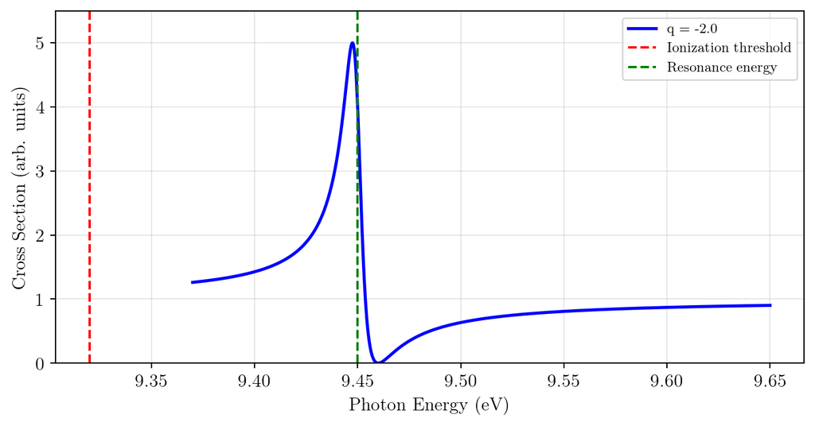

```python
import numpy as np
import matplotlib.pyplot as plt

plt.rcParams['text.usetex'] = True
plt.rcParams['font.family'] = 'serif'
plt.rcParams['font.size'] = 12


# Physical parameters for Beryllium
E_ionization = 9.32  # eV - ionization threshold
E_resonance = 9.45   # eV - doubly excited 2p^2 state
Gamma = 0.01         # eV - autoionization width (~10 meV, typical value)

# Energy range around the resonance
E = np.linspace(E_ionization+0.05, 9.65, 1000)

# Reduced energy variable
epsilon = (E - E_resonance) / (Gamma / 2)

# Function to calculate Fano profile
def fano_profile(epsilon, q):
    return (q + epsilon)**2 / (1 + epsilon**2)

# Create figure with multiple q values
fig, ax = plt.subplots(figsize=(7.5, 4))



# Different asymmetry parameters to demonstrate the effect
q = -2.0 #[-13.38, 1.0, 3.0, -2.0]

sigma = fano_profile(epsilon, q)

ax.plot(E, sigma, 'b-', linewidth=2, label=f'q = {q}')
ax.axvline(E_ionization, color='red', linestyle='--', linewidth=1.5,
               label='Ionization threshold')
ax.axvline(E_resonance, color='green', linestyle='--', linewidth=1.5,
               label='Resonance energy')

ax.set_xlabel('Photon Energy (eV)', fontsize=12)
ax.set_ylabel('Cross Section (arb. units)', fontsize=12)
ax.grid(True, alpha=0.3)
ax.legend(fontsize=9)
ax.set_ylim([0, max(sigma) * 1.1])

plt.tight_layout()

plt.show()
```

## 2.4 Core Holes and Auger Decay

While autoionization involves energy transfer between two *excited* electrons, a closely related process occurs after **inner-shell ionization** or **core excitation**. When an inner-shell electron (for instance, from the $1s$ orbital) is removed or excited, a **core hole** is created. The atom is then in a highly unstable state with excess internal energy, and it can relax through two competing pathways:

1. **Radiative decay (fluorescence):**  
   A higher-lying electron fills the core hole, and the excess energy is emitted as a photon (often an **X-ray**).
2. **Auger decay:**  
   Instead of emitting a photon, the released energy is transferred to another electron, which is then **ejected** from the atom with a characteristic kinetic energy. This process can be represented schematically as:

   $$A^{**} \;\longrightarrow\; A^{+} + e^-$$

   where $A^{**}$ denotes the atom with a core hole, and the emitted **Auger electron** carries away the energy difference between the initial and final electronic configurations.

### Competition Between Fluorescence and Auger Decay

The relative probability of these two decay channels is described by the **fluorescence yield**—the fraction of core-hole decays that produce a photon rather than an Auger electron. This yield depends strongly on the **atomic number $Z$**:

- For **light elements** ($Z \lesssim 30$), **Auger decay dominates**, since electron–electron interactions are strong compared to radiative coupling.
- For **heavy elements**, radiative rates increase rapidly (approximately $\propto Z^4$), and **fluorescence** becomes dominant.

Typical trends:

| Atomic number range | Dominant process | Approximate fluorescence yield |
| --- | --- | --- |
| $Z < 30$ | Auger decay | ≈ 10% |
| $Z \sim 30$–50 | Comparable | 10–50% |
| $Z > 50$ | Fluorescence | >80% |

In summary, **Auger decay** is a non-radiative relaxation mechanism driven entirely by **electron–electron interaction**, closely analogous to **autoionization**, but initiated by the creation of a **core hole** rather than a doubly excited state. It plays a central role in **surface analysis (Auger electron spectroscopy)**, **radiation damage**, and **inner-shell dynamics** in atoms and molecules.